# Project-Performance-Predicting Course Enrollment

Rich McGowan

April 22, 2018

#### The purpose of this analysis is to perform some basic (“naive”) executions of the model.

#### The first step is to initialize the project: After the project has been created in the target directory make sure the ProjectTemplate package is installed and loaded. The COURSE_CAPACITY_DATA.csv and TOTAL_ENRL_ATTEMPTS_BY_COURSE files have been moved into the data folder of the project and will be loaded into the Environment. This will also load all necessary packages (designated in the config file of the project).

#### The COURSE_CAPACITY_DATA.csv file contains approximately 13K rows of course schedule statisics for terms between Fall of 2016 and the Spring of 2018. The data frame is intended to facilitate the prediction of ultimate Enrollment Totals per scheduled course (for all primary/enrollmment scheduled sections).

```r
course_capacity_local <- tbl_df(COURSE.CAPACITY.DATA)
```

```r
clean_course_capacity_local <- course_capacity_local %>% filter(PercentFull<=2.0)
```

#### Plot some data points from the local data frame: visualize the relationship between the Total Course Capacity and Total Enrolled Students.

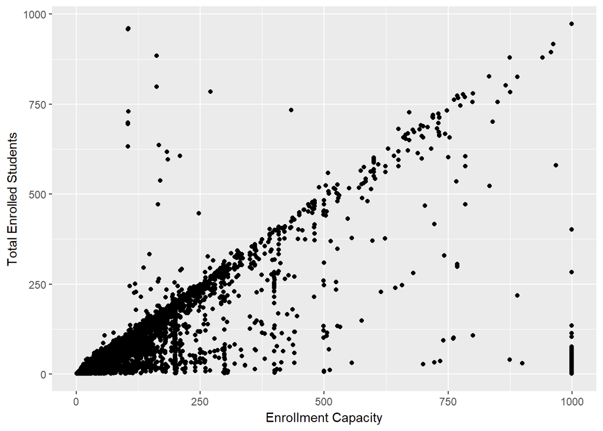

```r
ggplot(clean_course_capacity_local, aes(x= TotalCapacity, y = EnrlTotal)) + geom_point() + labs(x = 'Enrollment Capacity', y = 'Total Enrolled Students')
```

#### Run a simple linear regression using Total Course Capacity as the lone linear predictor of the response variable Enrollment Total. Show the results of the linear regression stored in an object called “model1”

```r
model1 <- lm(EnrlTotal~TotalCapacity,data = clean_course_capacity_local)
summary(model1)
```

```
##
## Call:
## lm(formula = EnrlTotal ~ TotalCapacity, data = clean_course_capacity_local)
##
## Residuals:
##     Min      1Q  Median      3Q     Max
## -343.76  -21.21  -12.43    6.88  904.20
##
## Coefficients:
##                Estimate Std. Error t value Pr(>|t|)
## (Intercept)   22.984316   0.695231   33.06   <2e-16 ***
## TotalCapacity  0.322101   0.004236   76.04   <2e-16 ***
## ---
## Signif. codes:  0 '***' 0.001 '**' 0.01 '*' 0.05 '.' 0.1 ' ' 1
##
## Residual standard error: 70 on 13143 degrees of freedom
## Multiple R-squared:  0.3055, Adjusted R-squared:  0.3055
## F-statistic:  5783 on 1 and 13143 DF,  p-value: < 2.2e-16
```

#### Add a regression line to the original plot

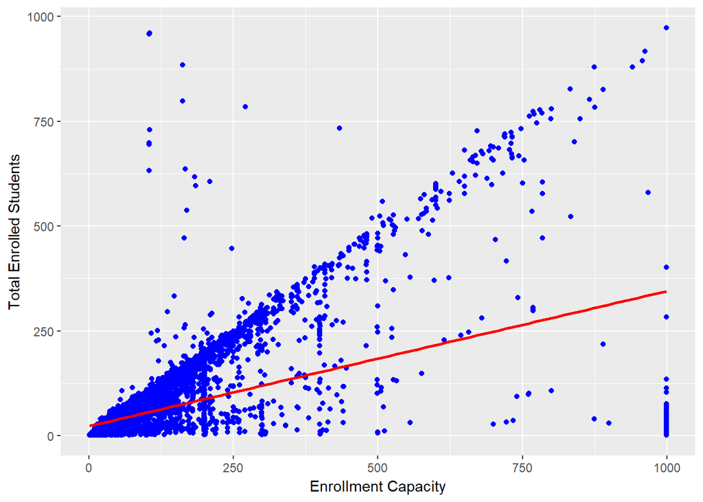

```r
ggplot(clean_course_capacity_local, aes(x= TotalCapacity, y = EnrlTotal)) + geom_point(color='blue') + geom_smooth(method = "lm", se = FALSE, color='Red') + labs(x = 'Enrollment Capacity', y = 'Total Enrolled Students')
```

# Project-Performance-Predicting Course Enrollment

Rich McGowan

April 22, 2018

#### The purpose of this analysis is to perform some basic (“naive”) executions of the model.

#### The first step is to initialize the project: After the project has been created in the target directory make sure the ProjectTemplate package is installed and loaded. The COURSE_CAPACITY_DATA.csv and TOTAL_ENRL_ATTEMPTS_BY_COURSE files have been moved into the data folder of the project and will be loaded into the Environment. This will also load all necessary packages (designated in the config file of the project).

#### The COURSE_CAPACITY_DATA.csv file contains approximately 13K rows of course schedule statisics for terms between Fall of 2016 and the Spring of 2018. The data frame is intended to facilitate the prediction of ultimate Enrollment Totals per scheduled course (for all primary/enrollmment scheduled sections).

```r
course_capacity_local <- tbl_df(COURSE.CAPACITY.DATA)
```

```r
clean_course_capacity_local <- course_capacity_local %>% filter(PercentFull<=2.0)
```

#### Plot some data points from the local data frame: visualize the relationship between the Total Course Capacity and Total Enrolled Students.

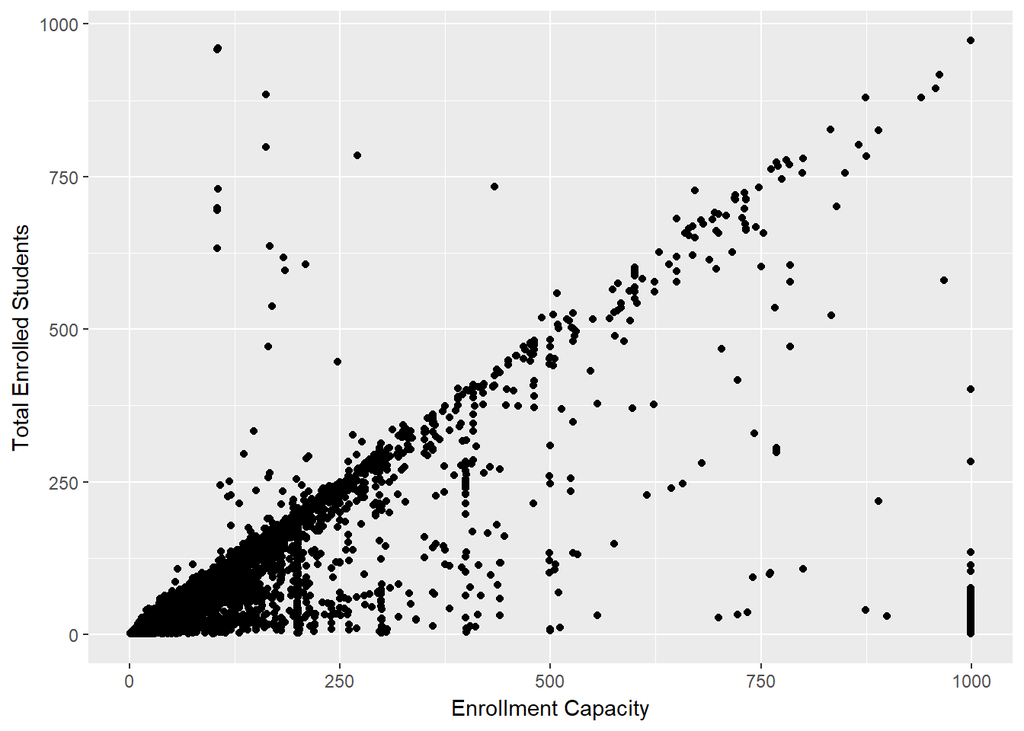

```r
ggplot(clean_course_capacity_local, aes(x= TotalCapacity, y = EnrlTotal)) + geom_point() + labs(x = 'Enrollment Capacity', y = 'Total Enrolled Students')
```

#### Run a simple linear regression using Total Course Capacity as the lone linear predictor of the response variable Enrollment Total. Show the results of the linear regression stored in an object called “model1”

```r
model1 <- lm(EnrlTotal~TotalCapacity,data = clean_course_capacity_local)
summary(model1)
```

```
##
## Call:
## lm(formula = EnrlTotal ~ TotalCapacity, data = clean_course_capacity_local)
##
## Residuals:
##     Min      1Q  Median      3Q     Max
## -343.76  -21.21  -12.43    6.88  904.20
##
## Coefficients:
##                Estimate Std. Error t value Pr(>|t|)
## (Intercept)   22.984316   0.695231   33.06   <2e-16 ***
## TotalCapacity  0.322101   0.004236   76.04   <2e-16 ***
## ---
## Signif. codes:  0 '***' 0.001 '**' 0.01 '*' 0.05 '.' 0.1 ' ' 1
##
## Residual standard error: 70 on 13143 degrees of freedom
## Multiple R-squared:  0.3055, Adjusted R-squared:  0.3055
## F-statistic:  5783 on 1 and 13143 DF,  p-value: < 2.2e-16
```

#### Add a regression line to the original plot

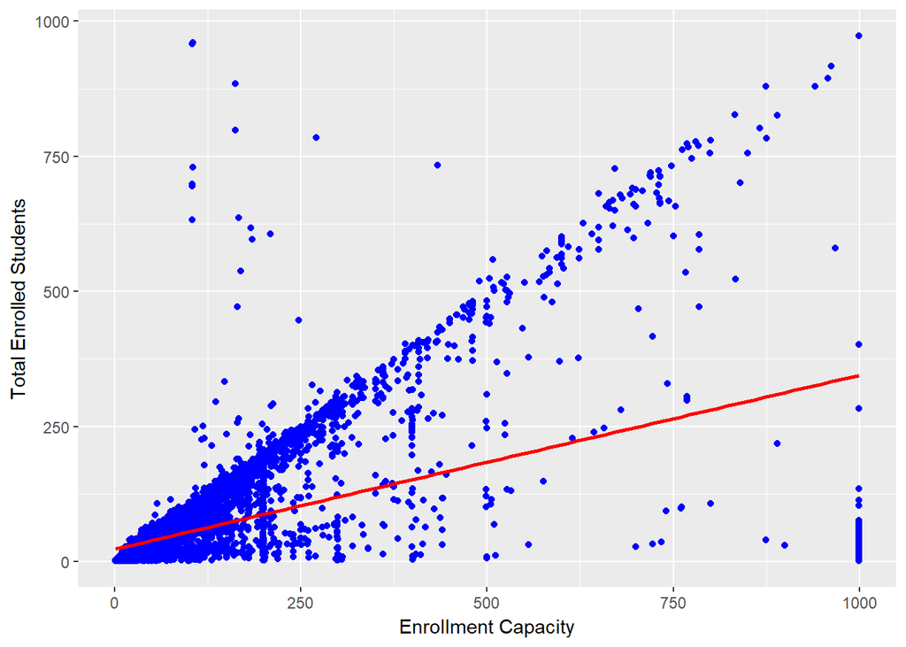

```r
ggplot(clean_course_capacity_local, aes(x= TotalCapacity, y = EnrlTotal)) + geom_point(color='blue') + geom_smooth(method = "lm", se = FALSE, color='Red') + labs(x = 'Enrollment Capacity', y = 'Total Enrolled Students')
```